# Medically Relevant Genes

Nate Olson

2020-01-30

# 1 Background

### 1.0.1 Objective

Summarize and characterize medically relevant gene list to aid description of the list in manuscript and for characterization plan development.

### 1.0.2 Hypotheses about different classes of regions not covered by v4.1

1. Small regions excluded due to long homopolymers
2. Small regions excluded due to complex variants
3. Large regions excluded due to putative SV
   1. Real SV
   2. False SV due to seg dup or other repeat structure
4. Large difficult to map regions/seg dups
5. Long tandem repeats
6. True duplications (CNVs) in HG002
7. Incorrectly identified duplications (CNVs) in HG002 (e.g., due to slightly higher than normal coverage)
8. Errors in GRCh37

### 1.0.3 Next Steps

- Identify uncharacterized regions excluded due to filtered small variants
- Look at number of genes with full characterization after excluding assumed homopolymers and small var discrepancies

# 2 Load Data

## 2.1 Medically Relevant Gene List Table

```r
gene_list_file <- "GRCh37_characterizations_assembly_contig_coverages_merged.xlsx"
gene_list_df <- read_xlsx(here("data", gene_list_file),
                          .name_repair = "universal")
```

## 2.2 Uncharacterized Regions

```r
comp_bed_file <- paste0("HG002_GRCh37_1_22_v4.1_draft_benchmark_complement_",
                        "intersect_GRCh37_Mandelker_COSMIC_ENSEMBLE_IDs_",
                        "and_geneName_primary_assembly_only_slop20000.bed")
overlap_compliment <- read_tsv(here("data",comp_bed_file),
                               col_names = c("Chromosome", "start","end",
                                             "Gene.Symbol","ensamble_id")) %>%
  mutate(region_size = end - start)
```

### 2.2.1 Callset Table

```r
callset_tbl <- read_tsv(here("data","callsettable_22_v4_1.txt"))
```

### 2.2.2 Uncharacterized Regions

```r
cnames = c("Chromosome", "start","end", "Gene.Symbol","ensamble_id",
           "n_features", "covered_bases", "region_size", "frac_covered")
cov_bed_list <- list.files(here("intermediate","complement_coverage"),
                         full.names = TRUE) %>%
  set_names(str_remove(., ".*comp_cov_"))

cov_bed_df <- cov_bed_list %>%
  map_dfr(read_tsv,
          col_names = cnames,
          col_types = "cddccdddd",
          .id = "difficult_bed") %>%
  unique() ## Not sure why there are duplicate entries in the data frame
```

# 3 Tidying Data

**helper functions**

```r
tidy_pct_bases <- function(df){
  df %>%
    gather(key = "region", value = "value", -Gene.Symbol) %>%
    filter(!is.na(value)) %>%
    mutate(metric = if_else(str_detect(region, "Bases.overlap"),
                            "bases", "percent")) %>%
    mutate(region = str_remove(region, "Bases.overlap.with."),
           region = str_remove(region, "Percent.of.gene.overlap.with."),
           region = str_remove(region, "Percent.of.gene.overlap.")) %>%
    spread(metric, value)
}
```

**Gene Coordinates**

```r
gene_coord_df <- gene_list_df %>%
  select(Chromosome, Start.minus.20kbp, End.plus.20kbp, Gene.Symbol)
```

```r
glimpse(gene_coord_df)
```

```
## Observations: 4,893
## Variables: 4
## $ Chromosome        <dbl> 1, 1, 1, 1, 1, 1, 1, 1, 1, 1, 1, 1, 1, 1, 1, 1…
## $ Start.minus.20kbp <dbl> 49091, 935503, 1147629, 1246694, 1930780, 2140…
## $ End.plus.20kbp    <dbl> 90008, 1011496, 1190421, 1290686, 1982192, 226…
## $ Gene.Symbol       <chr> "OR4F5", "AGRN", "B3GALT6", "TAS1R3", "GABRD",…
```

**Benchmarkset Overlap**

```r
benchmark_overlap <- gene_list_df %>%
  select(Gene.Symbol, contains("v4.1"), contains("SV.0.6"), -contains("CNV")) %>%
  tidy_pct_bases() %>%
  mutate(region = str_remove(region, "GIAB.expanded.by..150.Tier1andTier2.")) %>%
  rename(benchmark_set = region)
```

```r
glimpse(benchmark_overlap)
```

```
## Observations: 9,786
## Variables: 4
## $ Gene.Symbol   <chr> "A1CF", "A1CF", "A2M", "A2M", "A4GALT", "A4GALT", …
## $ benchmark_set <chr> "SV.0.6", "v4.1.draft", "SV.0.6", "v4.1.draft", "S…
## $ bases         <dbl> 0, 123327, 0, 87926, 1880, 63214, 300, 47850, 301,…
## $ percent       <dbl> 0.000000000, 0.976723742, 0.000000000, 0.992784960…
```

**Read Coverage**

```r
gene_cov_df <- gene_list_df %>%
  select(Gene.Symbol, contains("cover")) %>%
  gather(key = "analysis", value = "value", -Gene.Symbol) %>%
  filter(!is.na(value)) %>%
  mutate(
    data_set = case_when(
      str_detect(analysis, "CCS") ~ "CCS",
      str_detect(analysis, "10X") ~ "10X",
      str_detect(analysis, "ONT") ~ "ONT"),
    cov_stat = if_else(
      str_detect(analysis, "average"),
      "avg_cov",
      str_extract(analysis,
                  "(?<=covered.by.).*(?=.CCS|.ONT|.10X)"))
  ) %>%
  mutate(cov_stat = str_replace(cov_stat, "at.least.", "bp_cov_by_")) %>%
  select(-analysis) %>%
  spread(cov_stat, value)
```

```r
glimpse(gene_cov_df)
```

```
## Observations: 14,571
## Variables: 5
## $ Gene.Symbol    <chr> "A1CF", "A1CF", "A1CF", "A2M", "A2M", "A2M", "A4G…
## $ data_set       <chr> "10X", "CCS", "ONT", "10X", "CCS", "ONT", "10X", …
## $ avg_cov        <dbl> 62.15, 64.19, 63.01, 69.76, 58.05, 62.75, 43.68, …
## $ bp_cov_by_100X <dbl> 1867, 0, 0, 3067, 0, 0, 0, 0, 0, 1437, 0, 0, 1608…
## $ bp_cov_by_20X  <dbl> 126241, 1, 1, 88557, 1, 1, 68102, 1, 1, 48669, 1,…
```

**Difficult region overlap**

```r
difficult_regions_df <- gene_list_df %>%
  select(Gene.Symbol,
         contains("overlap"),  contains("CNV"),
         -contains("v4.1"), -contains("SV.0.6")) %>%
  tidy_pct_bases()

## Identifying subset of filtered difficult regions for analysis.
difficult_regions_df <- difficult_regions_df %>%
  mutate(exclusion = if_else(region %in% c("AllRepeats.gt.10kb",
                                           "intersect.Illumina..CCS..ONT.CNV.v4.1a",
                                           "segdups.with.count.gt.5.and.percent.identity.gte.990",
                                           "union.CCS.and.ONT.outlier.CNV.v4.1a.draft",
                                           "SP_Sponly",
                                           "vdj"),
                             "all", "others"))
```

```r
glimpse(difficult_regions_df)
```

```
## Observations: 39,144
## Variables: 5
## $ Gene.Symbol <chr> "A1CF", "A1CF", "A1CF", "A1CF", "A1CF", "A1CF", "A1C…
## $ region      <chr> "AllRepeats.gt.10kb", "Assembly.CNV", "inversions", …
## $ bases       <dbl> 0, 0, 0, 0, 4940, 0, 0, 0, 0, 0, 0, 0, 1018, 0, 0, 0…
## $ percent     <dbl> 0.00000000, 0.00000000, 0.00000000, 0.00000000, 0.03…
## $ exclusion   <chr> "all", "others", "others", "others", "others", "all"…
```

**Assembly Coverage**

```r
asm_coverage_df <- gene_list_df %>%
  select(Gene.Symbol, H1.Length.Ratio, H2.Length.Ratio, Number.of.Hits)
```

```r
glimpse(asm_coverage_df)
```

```
## Observations: 4,893
## Variables: 4
## $ Gene.Symbol     <chr> "OR4F5", "AGRN", "B3GALT6", "TAS1R3", "GABRD", "…
## $ H1.Length.Ratio <dbl> NA, 1.003500, 1.020850, NA, 1.004420, NA, 1.0064…
## $ H2.Length.Ratio <dbl> NA, 0.998697, 1.025470, NA, 1.004400, NA, 1.0063…
## $ Number.of.Hits  <dbl> 0, 2, 2, 0, 2, 0, 2, 1, 2, 2, 2, 2, 2, 2, 2, 2, …
```

Preparing data frame for overlap characterization plots.

```r
gene_coord_v4_df <- benchmark_overlap %>%
  filter(benchmark_set == "v4.1.draft") %>%
    mutate(overlap_bins = cut(percent,
                            c(0,0.0000001, 0.50, 0.60, 0.70, 0.80,
                              0.90, 0.95, 0.99, 1.00),
                            include.lowest = TRUE),
           overlap_pct = percent,
           overlap_bp  = bases) %>%
  select(Gene.Symbol, overlap_bp, overlap_pct, overlap_bins) %>%
  left_join(gene_coord_df) %>%
  mutate(gene_size = End.plus.20kbp - Start.minus.20kbp,
         uncharacterized_bp = gene_size - overlap_bp) %>%
  filter(Chromosome %in% c(1:22))
```

# 4 Analysis

## 4.1 Breakdown of V4.1 Overlap

Summary of V4.1 GRCh37 benchnmark region overlap with combined medically relevant gene list.

**Take away:**

- Most genes covered by 95% or more by the small variant benchmark regions.
- ~ 3K uncharacterized based in each gene.

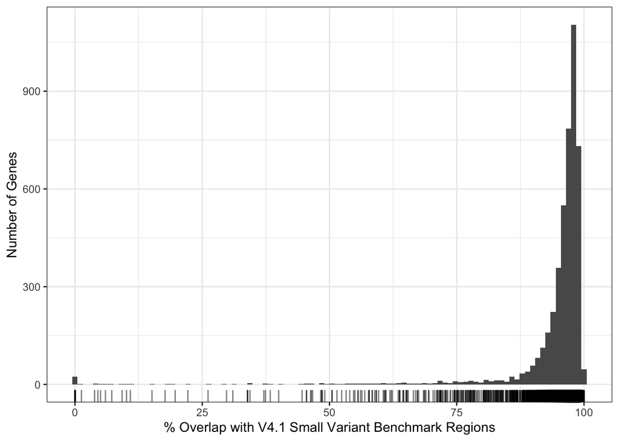

Figure 4.1: Histogram of the percent V4.1 benchmark set overlap by gene for combined medically relevant gene list. Rug plot used to help visualize genes in low frequency coverage histogram.

```r
ggplot(gene_coord_v4_df) +
  geom_histogram(aes(x = 100*overlap_pct), bins = 100) +
  geom_rug(aes(x = 100*overlap_pct), alpha = 0.5) +
  theme_bw() +
  labs(x = "% Overlap with V4.1 Small Variant Benchmark Regions",
       y = "Number of Genes")
```

```r
gene_coord_v4_df %>%
group_by(overlap_bins) %>%
summarise(count = n()) %>%
  knitr::kable(caption = "Number of genes for each benchmark coverage bins.")
```

Table 4.1: Number of genes for each benchmark coverage bins.

| overlap_bins | count |
| --- | --- |
| [0,1e-07] | 24 |
| (1e-07,0.5] | 35 |
| (0.5,0.6] | 22 |
| (0.6,0.7] | 31 |
| (0.7,0.8] | 70 |
| (0.8,0.9] | 209 |
| (0.9,0.95] | 778 |
| (0.95,0.99] | 3113 |
| (0.99,1] | 279 |

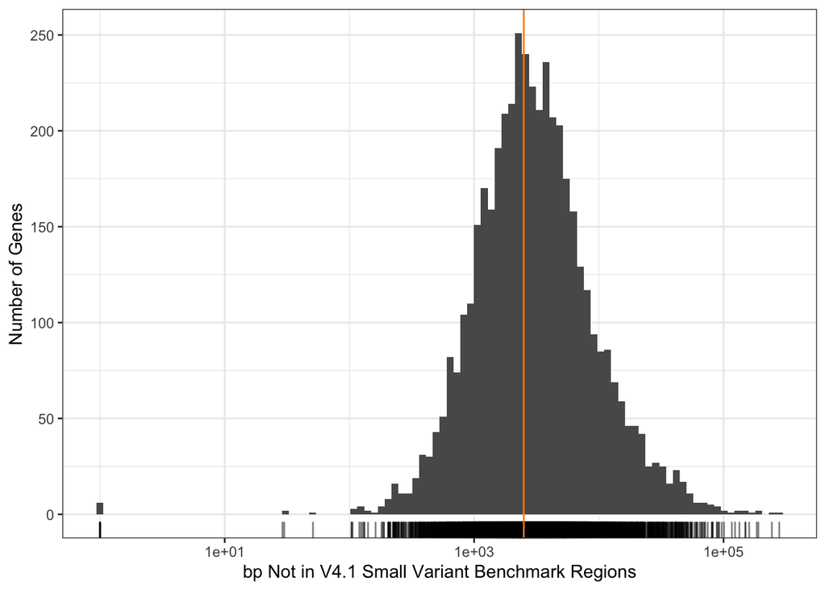

Figure 4.2: Distribtuion in the number of uncharacterized bases, bases not in the small variant benchmark regions, for individual medicallly relevant genes.

```r
ggplot(gene_coord_v4_df) +
  geom_histogram(aes(x = uncharacterized_bp + 1), bins = 100) +
  geom_rug(aes(x = uncharacterized_bp + 1), alpha = 0.5) +
  geom_vline(aes(xintercept = 2500), color = "darkorange") +
  theme_bw() +
  scale_x_log10() +
  labs(x = "bp Not in V4.1 Small Variant Benchmark Regions",
       y = "Number of Genes")
```

Summary statistics for number of uncharacterized base pairs per gene.

```r
summary(gene_coord_v4_df$uncharacterized_bp)
```

```
##    Min. 1st Qu.  Median    Mean 3rd Qu.    Max.
##       0    1509    2907    5933    5752  280029
```

## 4.2 Uncharacterized Regions

Summary of uncharacterized regions (bases outside the V4.1 benchmark set) in the combined medically relevant gene list for GRCh37.

**Take away:**

Summary statistics for number of uncharacterized regions per gene.

```r
unchar_region_count_df <- overlap_compliment %>%
  group_by(Gene.Symbol) %>%
  summarise(count = n())

summary(unchar_region_count_df$count)
```

```
##    Min. 1st Qu.  Median    Mean 3rd Qu.    Max.
##    1.00    9.00   16.00   25.56   29.00  736.00
```

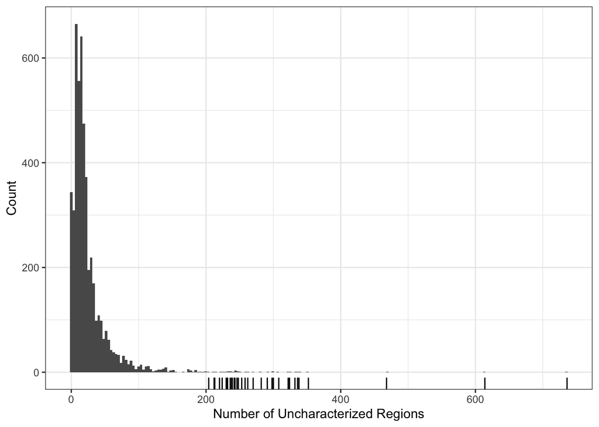

Figure 4.3: Distribution in the number uncharacterized regions per gene.

```r
ggplot(unchar_region_count_df) +
    geom_histogram(aes(x = count), bins = 200) +
  geom_rug(data = filter(unchar_region_count_df, count > 200),
           aes(x = count)) +
    theme_bw() +
    labs(x = "Number of Uncharacterized Regions", y = "Count")
```

Summary statistics for uncharacterized region size.

```r
summary(overlap_compliment$region_size)
```

```
##      Min.   1st Qu.    Median      Mean   3rd Qu.      Max.
##       1.0     102.0     104.0     574.6     129.0 2281764.0
```

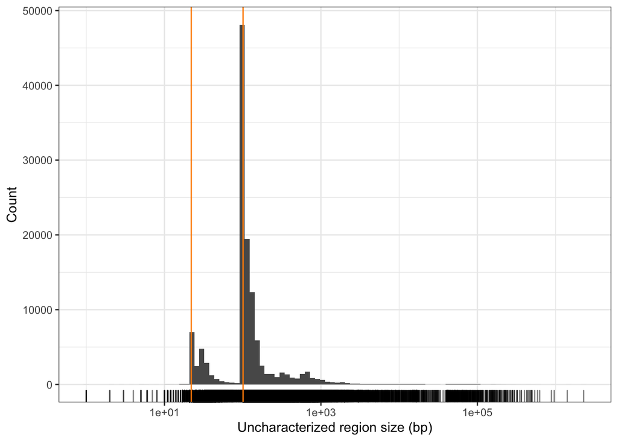

Figure 4.4: Uncharacterized region size distribution

```r
ggplot(overlap_compliment) +
  geom_histogram(aes(x = region_size), bins = 100) +
  geom_rug(aes(x = region_size), alpha = 0.5) +
  geom_vline(aes(xintercept = 101), color = "darkorange") +
  geom_vline(aes(xintercept = 22), color = "darkorange") +
  scale_x_log10() +
  theme_bw() +
  labs(x = "Uncharacterized region size (bp)", y = "Count")
```

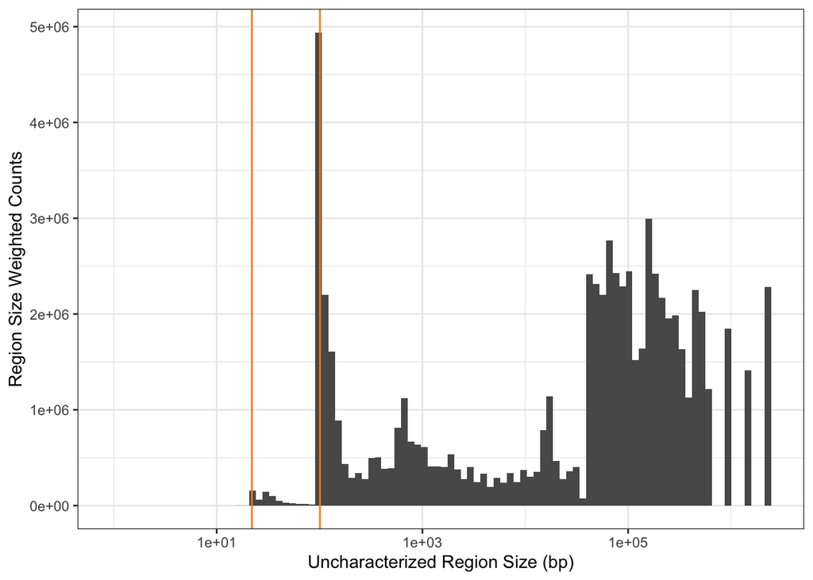

Figure 4.5: Uncharacterized region size distribution weighted by region size.

```r
ggplot(overlap_compliment) +
  geom_histogram(aes(x = region_size, weight = region_size), bins = 100) +
  geom_vline(aes(xintercept = 101), color = "darkorange") +
  geom_vline(aes(xintercept = 22), color = "darkorange") +
  scale_x_log10() +
  theme_bw() +
  labs(x = "Uncharacterized Region Size (bp)",
       y = "Region Size Weighted Counts")
```

## 4.3 Gene Level Difficult Region Coverage

Characterization of uncovered regions by difficult region bed files used in the small variant integration pipeline. The bed files to define difficult regions that are excluded from one or more of the input variant callsets based on unknow biases and limitations of the individual methods used to generate each input variant callset.

[figure not shown]

Figure 4.6: Table of excluded difficult region bed files by callset. Regions on the left of the plot are excluded from all callsets.

```r
callset_tbl %>%
  select(-`#Platform`, -Dataset, -annotationsFile, -vcfAll, -callableBed) %>%
  gather("region", "exclude", -Callset) %>%
  group_by(region) %>%
  mutate(total_exclude = sum(exclude)) %>%
  ungroup() %>%
  mutate(region = fct_reorder(region, -total_exclude)) %>%
  ggplot() +
  geom_raster(aes(y = Callset,
                  x = region,
                  fill = as.logical(exclude))) +
  theme_bw() +
  theme(axis.text.x = element_text(angle = 90, hjust = 1)) +
  labs(x = "Difficult Region Bed File", fill = "Excluded")
```

```r
inner_join(difficult_regions_df, gene_coord_v4_df) %>%
  filter(percent != 0) %>%
  mutate(combined_overlap = percent + overlap_pct) %>%
  filter(combined_overlap == 1) %>%
  select(Gene.Symbol, region, Chromosome, percent, overlap_pct) %>%
  spread(region, percent, fill = 0) %>%
  arrange(Chromosome) %>%
  knitr::kable(caption = "Genes excluded from benchmark set due to a single difficult region. Overlap percent is the percent overlap with V4.1 GRCh37 benchmark regions, Segdups are defined as ..., SP_Sponly is ..., vdj is ...")
```

Table 4.2: Genes excluded from benchmark set due to a single difficult region. Overlap percent is the percent overlap with V4.1 GRCh37 benchmark regions, Segdups are defined as …, SP_Sponly is …, vdj is …

| Gene.Symbol | Chromosome | overlap_pct | segdups | SP_Sponly | vdj |
| --- | --- | --- | --- | --- | --- |
| FCGR1A | 1 | 0 | 1 | 0 | 0 |
| OR4F5 | 1 | 0 | 1 | 0 | 0 |
| IGKV1-5 | 2 | 0 | 0 | 0 | 1 |
| GYPE | 4 | 0 | 1 | 0 | 0 |
| NCF1C | 7 | 0 | 1 | 0 | 0 |
| H19 | 11 | 0 | 0 | 1 | 0 |
| DPY19L2 | 12 | 0 | 1 | 0 | 0 |
| IGHA1 | 14 | 0 | 0 | 0 | 1 |
| IGHG1 | 14 | 0 | 1 | 0 | 1 |
| IGHG2 | 14 | 0 | 1 | 0 | 1 |
| IGHM | 14 | 0 | 0 | 0 | 1 |
| IGHV3-21 | 14 | 0 | 0 | 0 | 1 |
| CCL3L1 | 17 | 0 | 1 | 0 | 0 |
| CCL4L1 | 17 | 0 | 1 | 0 | 0 |
| U2AF1 | 21 | 0 | 0 | 1 | 0 |

```r
inner_join(difficult_regions_df, gene_coord_v4_df) %>%
  filter(exclusion == "all",
         percent != 0) %>%
  mutate(combined_overlap = percent + overlap_pct) %>%
  filter(combined_overlap != 1) %>%
  arrange(-combined_overlap, Gene.Symbol) %>%
  select(Gene.Symbol, region, combined_overlap, overlap_pct, percent) %>%
  DT::datatable(caption = "Difficult region overlap by gene for a subset of the difficult bed files excluded for all input callsets.")
```

|  | Gene.Symbol | region | combined_overlap | overlap_pct | percent |
| --- | --- | --- | --- | --- | --- |
| 1 | CBS | SP_Sponly | 0.999952943 | 0.038571339 | 0.961381604 |
| 2 | CCL3L1 | SP_Sponly | 0.998663134 | 0 | 0.998663134 |
| 3 | KCNE1 | SP_Sponly | 0.998058437 | 0.343903017 | 0.65415542 |
| 4 | RCAN1 | SP_Sponly | 0.992957796 | 0.974528348 | 0.018429448 |
| 5 | NCOA4 | SP_Sponly | 0.988861122 | 0.762715997 | 0.226145125 |
| 6 | DGCR6 | SP_Sponly | 0.984837171 | 0 | 0.984837171 |
| 7 | KCNE2 | SP_Sponly | 0.983384355 | 0.621323762 | 0.362060593 |
| 8 | CRYAA | SP_Sponly | 0.983309359 | 0.101194146 | 0.882115213 |
| 9 | NOTCH2 | SP_Sponly | 0.982283505 | 0.490826198 | 0.491457307 |
| 10 | ABCG5 | AllRepeats.gt.10kb | 0.977467504 | 0.9206091 | 0.056858404 |

[output cut: 33 more lines]

## 4.4 Uncharacterized Region Difficult Region Analysis

```r
cov_bed_df %>%
  filter(frac_covered == 1) %>%
  group_by(difficult_bed) %>%
  summarise(count = n()) %>%
  arrange(-count) %>%
  DT::datatable(rownames = FALSE, caption = "Number of uncharacterized regions fully covered by each difficult region bed file.")
```

| difficult_bed | count |
| --- | --- |
| HG002_GRCh37_filteredsites.bed | 72215 |
| AllTandemRepeatsandHomopolymers_slop5.bed.gz | 21389 |
| AllHomopolymers_gt6bp_imperfectgt10bp_slop5.bed.gz | 16206 |
| HG002_HG003_HG004_allsvs_merged.bed.gz | 10712 |
| expanded_150_HG002_SVs_Tier1plusTier2_v0.6.1.bed | 3271 |
| HG002_GIAB_highconf_IllFB-IllGATKHC-CG-Ion-Solid_CHROM1-22_v3.2.2_highconf_varswithin50bp.bed.gz | 2564 |
| expanded_150_HG002_SVs_Tier1plusTier2_v0.6.1_Tier1overlap.bed | 1870 |
| expanded_150_HG002_SVs_Tier1plusTier2_v0.6.1_noTier1overlap.bed | 1400 |
| AllTandemRepeats_gt100bp_slop5.bed.gz | 883 |
| AllTandemRepeats_201to10000bp_slop5.bed.gz | 582 |

[output cut: 21 more lines]

### 4.4.1 Uncharacterized Region Exploratory Analysis

```r
## Uncharacterized regions completely covered by one or more difficult bed
diff_covered_uncharacterized_regions <- cov_bed_df %>%
  filter(frac_covered == 1) %>%
  select(Chromosome, start, end, Gene.Symbol, ensamble_id) %>%
  unique()

uncharacterized_regions_df <- diff_covered_uncharacterized_regions %>%
  mutate(diff_covered = 1) %>%
  full_join(overlap_compliment) %>%
  mutate(diff_covered = if_else(is.na(diff_covered), "not fully covered", "fully covered"))
```

**Take Away**

```r
uncharacterized_regions_df %>%
  group_by(diff_covered) %>%
  summarise(count = n())
```

```
## # A tibble: 2 x 2
##   diff_covered       count
##   <chr>              <int>
## 1 fully covered     110895
## 2 not fully covered  14020
```

```r
uncharacterized_regions_df %>%
  group_by(Gene.Symbol, diff_covered) %>%
  summarise(count = n()) %>%
  spread(diff_covered, count, fill = 0)  %>%
  mutate(fully_explained = if_else(`not fully covered` == 0, TRUE, FALSE)) %>%
  group_by(fully_explained) %>%
  summarise(count = n())
```

```
## # A tibble: 2 x 2
##   fully_explained count
##   <lgl>           <int>
## 1 FALSE            3930
## 2 TRUE              957
```

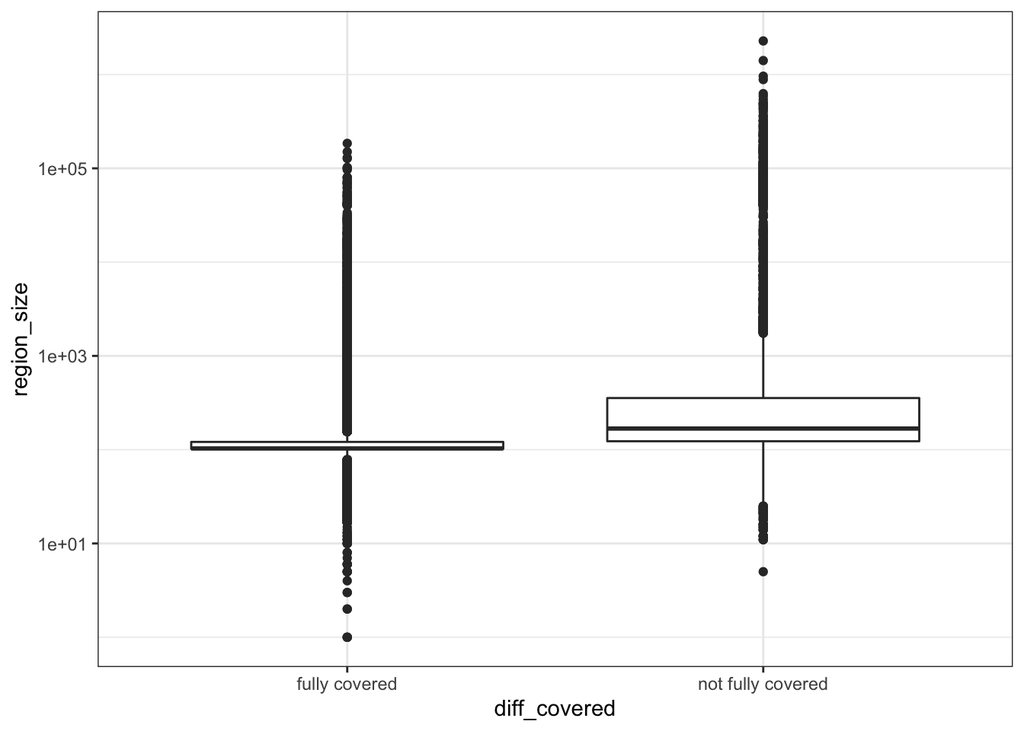

Figure 4.7: Distribution of uncharacterized region size for thoes completely or not completely covered by a difficult region bed file.

```r
uncharacterized_regions_df %>%
  ggplot() +
  geom_boxplot(aes(x = diff_covered, y = region_size)) +
  scale_y_log10() +
  theme_bw()
```

Genes with uncharacterized regions not fully covered by one or more difficult beds.

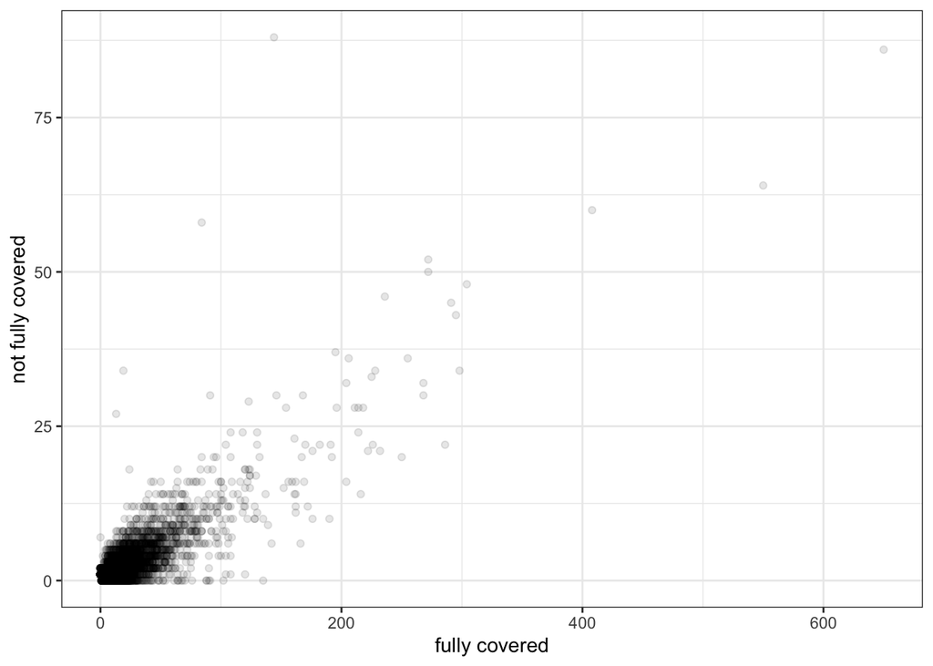

Figure 4.8: Regions per gene attributed to a difficult region type.

```r
uncharacterized_regions_df %>%
  group_by(Gene.Symbol, diff_covered) %>%
  summarise(count = n()) %>%
  spread(diff_covered, count, fill = 0) %>%
  ggplot() +
  geom_point(aes(x = `fully covered`, y = `not fully covered`), alpha = 0.1) +
  theme_bw()
```

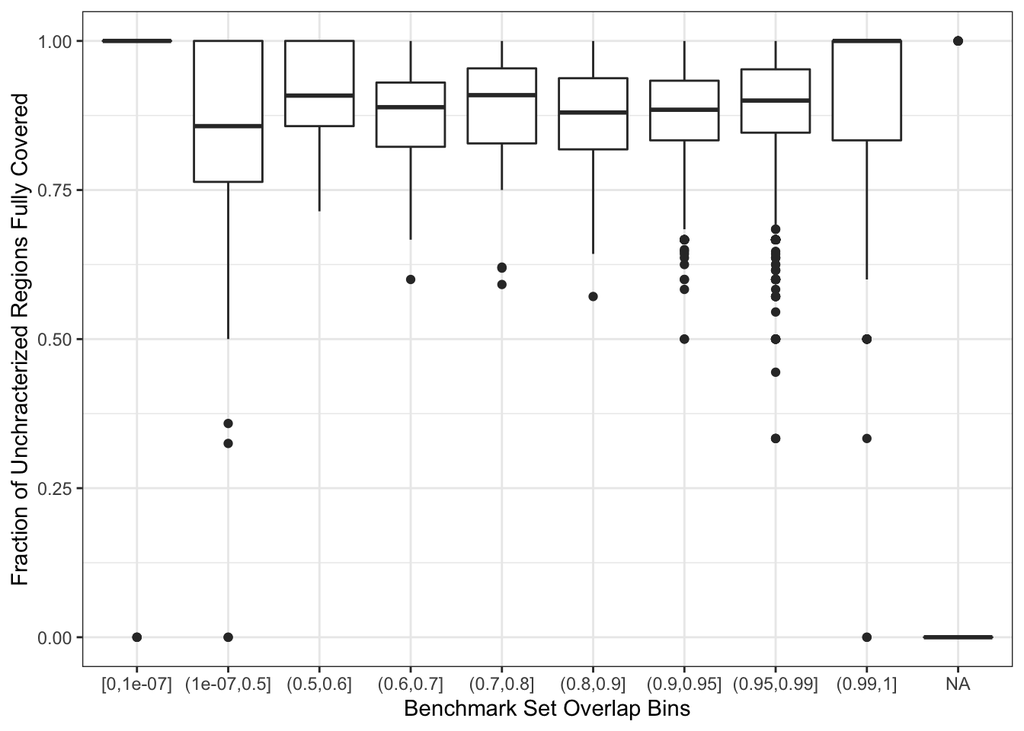

```r
uncharacterized_regions_df %>%
  group_by(Gene.Symbol, diff_covered) %>%
  summarise(count = n()) %>%
  spread(diff_covered, count, fill = 0) %>%
  left_join(gene_coord_v4_df) %>%
  mutate(frac_fully_covered = `fully covered`/ (`fully covered` + `not fully covered`)) %>%
  ggplot() +
  geom_boxplot(aes(y = frac_fully_covered, x = overlap_bins)) +
  theme_bw() +
  labs(x = "Benchmark Set Overlap Bins", y = "Fraction of Unchracterized Regions Fully Covered")
```

Genes not matching the uncharacterized region analysis form the gene_coord_v4_df– need to debug

```r
uncharacterized_regions_df %>%
  group_by(Gene.Symbol, diff_covered) %>%
  summarise(count = n()) %>%
  spread(diff_covered, count, fill = 0) %>%
  left_join(gene_coord_v4_df) %>%
  filter(is.na(overlap_bins))
```

```
## # A tibble: 332 x 11
## # Groups:   Gene.Symbol [332]
##    Gene.Symbol `fully covered` `not fully cove… overlap_bp overlap_pct
##    <chr>                 <dbl>            <dbl>      <dbl>       <dbl>
##  1 ABCB7                     0                1         NA          NA
##  2 ABCD1                     0                1         NA          NA
##  3 ACSL4                     0                1         NA          NA
##  4 AFF2                      0                1         NA          NA
##  5 AGTR2                     0                1         NA          NA
##  6 AIFM1                     0                1         NA          NA
##  7 ALAS2                     0                1         NA          NA
##  8 ALG13                     0                1         NA          NA
##  9 AMELX                     0                1         NA          NA
## 10 AMELY                     0                1         NA          NA
## # … with 322 more rows, and 6 more variables: overlap_bins <fct>,
## #   Chromosome <dbl>, Start.minus.20kbp <dbl>, End.plus.20kbp <dbl>,
## #   gene_size <dbl>, uncharacterized_bp <dbl>
```

**Considerations for difficult region bed overlap**

Regions fully covered by multiple difficult beds. Primarily due to some of the difficult beds being a super set of multiple difficult beds, e.g. All tandem repeats greater than 100bp and tandem repeats between 201 and 10kb.

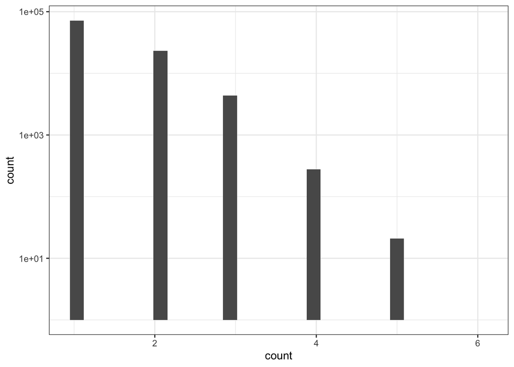

```r
cov_bed_df %>%
  filter(frac_covered == 1) %>%
  group_by(Chromosome, start, end, ensamble_id) %>%
  summarise(count = n()) %>%
  ggplot() + geom_histogram(aes(x = count)) +
  scale_y_log10() +
  theme_bw()
```

### 4.4.2 Homopolymer Analysis

**Take Away**

- Uncharacterized regions completely covered by the homopolymer bed file are all less than 80 bp with most around 20 bp.
- Not all uncharacterized regions less than 80 bp in size are fully covered by the homopolymer bed file but most are partially covered.

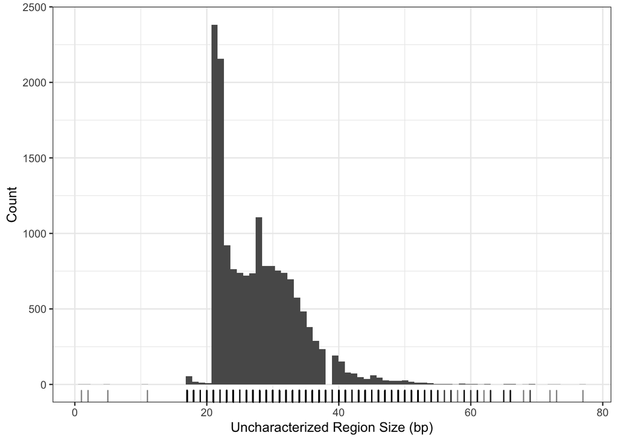

Figure 4.9: Distribution of region size for uncharacterized regions fully covered by the homopolymer difficult regions bed file.

```r
cov_bed_df %>%
  filter(difficult_bed == "AllHomopolymers_gt6bp_imperfectgt10bp_slop5.bed.gz") %>%
  filter(frac_covered == 1) %>%
  mutate(region_size_bins = cut_interval(region_size, n = 4)) %>%
    ggplot() +
      geom_histogram(aes(x = region_size), bins = 80) +
  geom_rug(aes(x = region_size), alpha = 0.5) +
      theme_bw() +
  labs(x = "Uncharacterized Region Size (bp)", y = "Count")
```

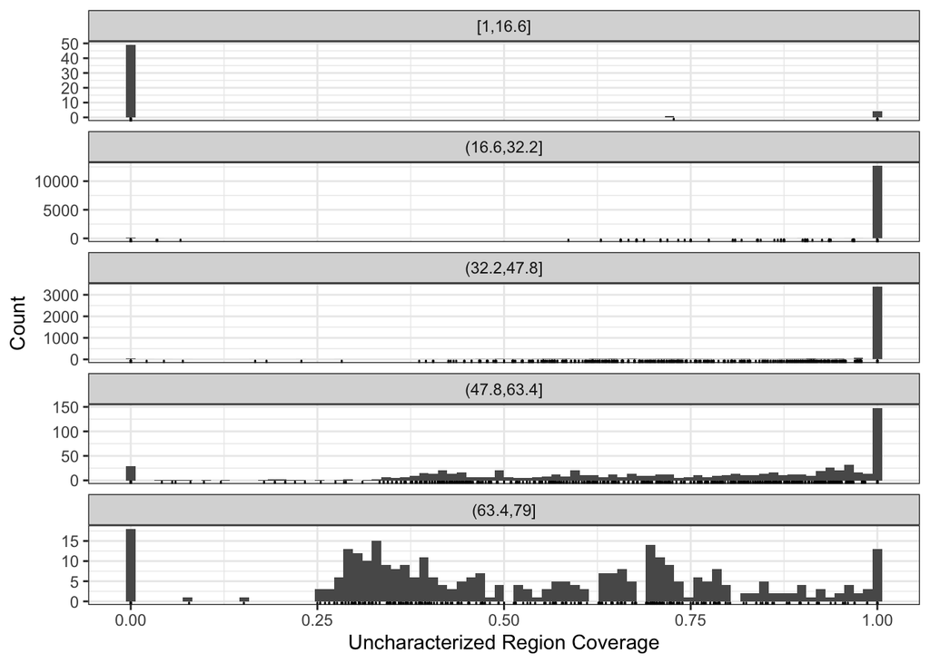

Figure 4.10: Coverage of uncharacerized regions less than 80 bp by the homopolymer difficult regions bed file.

```r
cov_bed_df %>%
  filter(difficult_bed == "AllHomopolymers_gt6bp_imperfectgt10bp_slop5.bed.gz") %>%
  filter(region_size < 80) %>%
  mutate(region_size_bins = cut_interval(region_size, n = 5)) %>%
  ggplot() +
  geom_histogram(aes(x = frac_covered), bins = 80) +
  geom_rug(aes(x = frac_covered)) +
  facet_wrap(~region_size_bins, ncol = 1, scales = "free_y") +
  theme_bw() +
  labs(x = "Uncharacterized Region Coverage", y = "Count")
```

### 4.4.3 SV Analysis

**Take Away**

- The SV difficult bed completely covers over 3000 uncharacterized regions covering a large size distribution.
- The size distributions of uncharacterized regions differs between thoes that do and do not overlap with the tier 1 SVs.
- Thoes not covered by the tier 1 SVs are good targets for initial exploratory manual curration.

```r
sv_unchar_df <- cov_bed_df %>%
  filter(str_detect(difficult_bed, "expanded_150_HG002_SVs")) %>%
  filter(frac_covered == 1)

## Annotating uncharacterized regions by SV tier overlap
full_sv <- sv_unchar_df %>%
  filter(difficult_bed == "expanded_150_HG002_SVs_Tier1plusTier2_v0.6.1.bed")
sv_tier_overlap <- sv_unchar_df %>%
  filter(difficult_bed != "expanded_150_HG002_SVs_Tier1plusTier2_v0.6.1.bed") %>%
  mutate(tier_overlap = str_extract(difficult_bed, "(?<=v0.6.1_).*(?=.bed)")) %>%
  select(-difficult_bed) %>%
  full_join(full_sv)
```

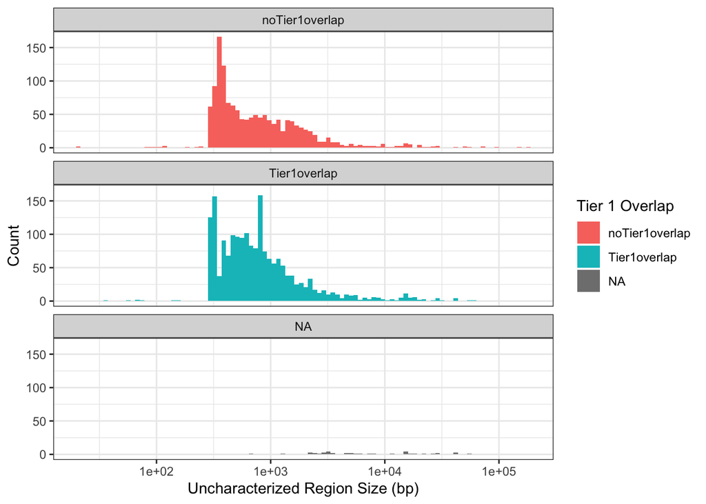

Figure 4.11: Uncharacterized regions fully covered by the expanded combined tier 1 and tier 2 V0.6.1 SVs.

```r
ggplot(sv_tier_overlap) +
  geom_histogram(aes(x = region_size, fill = tier_overlap), bins = 100) +
  scale_x_log10() +
  theme_bw() +
  facet_wrap(~tier_overlap, ncol = 1) +
  labs(x = "Uncharacterized Region Size (bp)", y = "Count", fill = "Tier 1 Overlap")
```

Uncharacterized regions not annotated as tier1 or no tier1 overlap due to error in tier 1 overlap annotation.

```r
sv_tier_overlap %>% filter(is.na(tier_overlap)) %>%
  DT::datatable()
```

|  | Chromosome | start | end | Gene.Symbol | ensamble_id | n_features | covered_bases | region_size | frac_covered | tier_overlap | difficult_bed |
| --- | --- | --- | --- | --- | --- | --- | --- | --- | --- | --- | --- |
| 1 | 1 | 66077682 | 66079938 | LEPR | ENSG00000116678 | 1 | 2256 | 2256 | 1 |  | expanded_150_HG002_SVs_Tier1plusTier2_v0.6.1.bed |
| 2 | 11 | 663953 | 692313 | DEAF1 | ENSG00000177030 | 2 | 28360 | 28360 | 1 |  | expanded_150_HG002_SVs_Tier1plusTier2_v0.6.1.bed |
| 3 | 12 | 2214072 | 2217367 | CACNA1C | ENSG00000151067 | 1 | 3295 | 3295 | 1 |  | expanded_150_HG002_SVs_Tier1plusTier2_v0.6.1.bed |
| 4 | 12 | 6040193 | 6042338 | VWF | ENSG00000110799 | 1 | 2145 | 2145 | 1 |  | expanded_150_HG002_SVs_Tier1plusTier2_v0.6.1.bed |
| 5 | 12 | 133365927 | 133371145 | GOLGA3 | ENSG00000090615 | 2 | 5218 | 5218 | 1 |  | expanded_150_HG002_SVs_Tier1plusTier2_v0.6.1.bed |
| 6 | 16 | 199995 | 218045 | HBM | ENSG00000206177 | 1 | 18050 | 18050 | 1 |  | expanded_150_HG002_SVs_Tier1plusTier2_v0.6.1.bed |
| 7 | 16 | 202846 | 218045 | HBA2 | ENSG00000188536 | 1 | 15199 | 15199 | 1 |  | expanded_150_HG002_SVs_Tier1plusTier2_v0.6.1.bed |
| 8 | 16 | 206679 | 218045 | HBA1 | ENSG00000206172 | 1 | 11366 | 11366 | 1 |  | expanded_150_HG002_SVs_Tier1plusTier2_v0.6.1.bed |
| 9 | 16 | 898080 | 912950 | LMF1 | ENSG00000103227 | 1 | 14870 | 14870 | 1 |  | expanded_150_HG002_SVs_Tier1plusTier2_v0.6.1.bed |
| 10 | 16 | 89062277 | 89063612 | CBFA2T3 | ENSG00000129993 | 1 | 1335 | 1335 | 1 |  | expanded_150_HG002_SVs_Tier1plusTier2_v0.6.1.bed |

[output cut: 30 more lines]

### 4.4.4 Read Depth Coverage

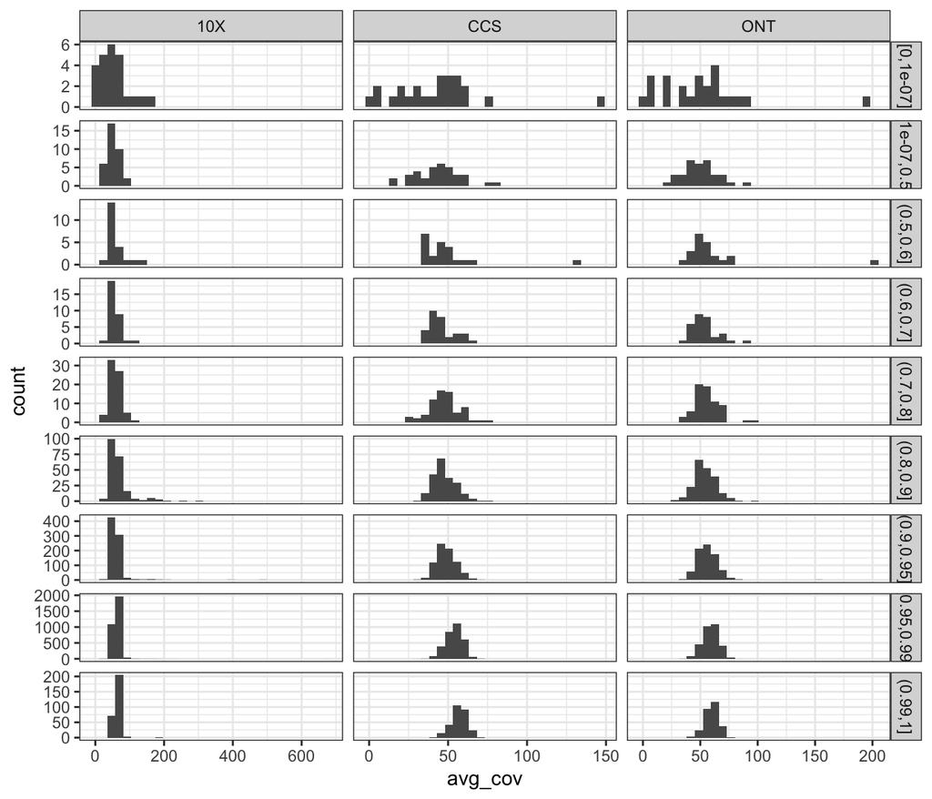

Figure 4.12: Mean read coverage distribution for the CCS, ONT, and 10X for the combined list of medically relevant gene stratified by the fraction of the gene in the V4.1 GRCh37 small variant benchmark set.

```r
left_join(gene_coord_v4_df, gene_cov_df) %>%
  ggplot() +
  geom_histogram(aes(x = avg_cov)) +
  facet_grid(overlap_bins ~ data_set, scales = "free") +
  theme_bw()
```

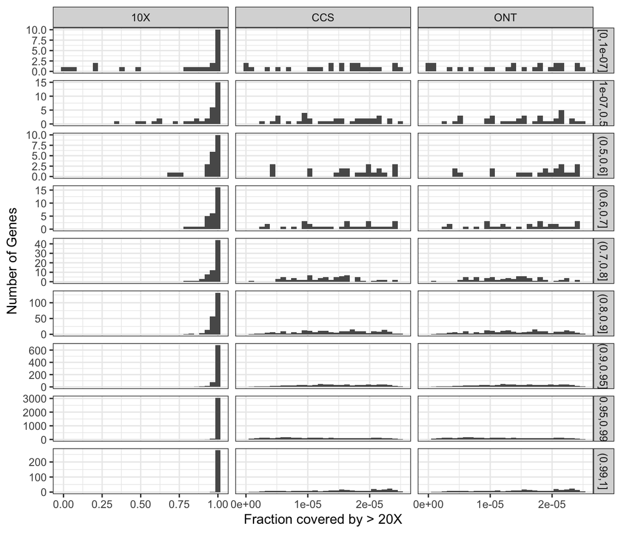

Figure 4.13: Fraction of Gene Covered at >20X by 10x, ONT, and CCS.

```r
left_join(gene_coord_v4_df, gene_cov_df) %>%
  ggplot() +
    geom_histogram(aes(x = bp_cov_by_20X/(End.plus.20kbp - Start.minus.20kbp))) +
    facet_grid(overlap_bins~data_set, scales = "free") +
  theme_bw() +
  labs(x = "Fraction covered by > 20X", y = "Number of Genes")
```

### 4.4.5 Assembly Coverage

```r
inner_join(gene_coord_v4_df, asm_coverage_df) %>%
  group_by(overlap_bins, Number.of.Hits) %>%
  summarise(count = n()) %>%
  spread(Number.of.Hits, count, fill = 0) %>%
  knitr::kable(caption = "Number of contigs that align to a gene by benchmark overlap bins.")
```

Table 4.3: Number of contigs that align to a gene by benchmark overlap bins.

| overlap_bins | 0 | 1 | 2 | 4 |
| --- | --- | --- | --- | --- |
| [0,1e-07] | 10 | 4 | 10 | 0 |
| (1e-07,0.5] | 17 | 2 | 16 | 0 |
| (0.5,0.6] | 9 | 6 | 7 | 0 |
| (0.6,0.7] | 8 | 5 | 18 | 0 |
| (0.7,0.8] | 19 | 8 | 43 | 0 |
| (0.8,0.9] | 42 | 14 | 153 | 0 |
| (0.9,0.95] | 44 | 33 | 701 | 0 |
| (0.95,0.99] | 78 | 55 | 2978 | 2 |
| (0.99,1] | 9 | 1 | 269 | 0 |

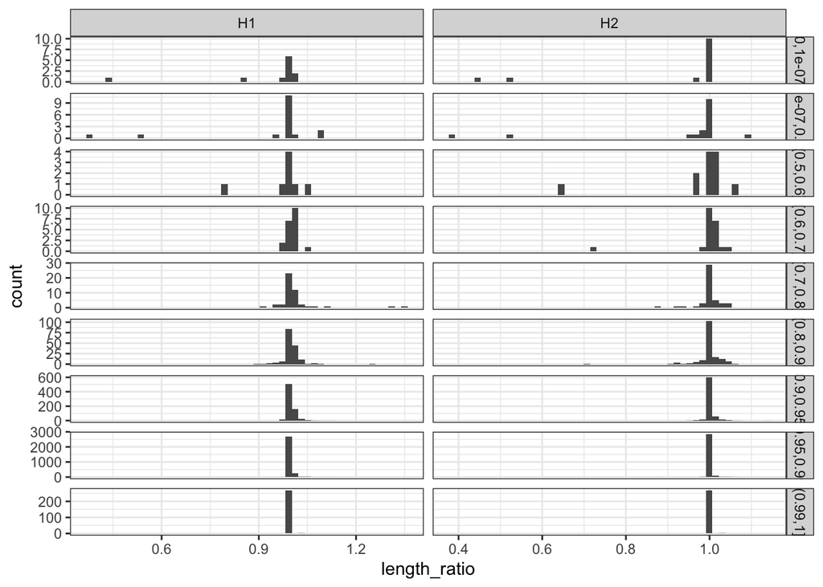

Figure 4.14: Distribution of the ratio of the assembly length to the reference gene length for the two haplotypes.

```r
tidy_hap_coverage <- asm_coverage_df %>%
  select(Gene.Symbol, starts_with("H")) %>%
  gather(key = "hap", value = "length_ratio", -Gene.Symbol) %>%
  mutate(hap = str_remove(hap, ".Length.Ratio")) %>%
  filter(!is.na(length_ratio))


inner_join(gene_coord_v4_df, tidy_hap_coverage) %>%
  ggplot() +
  geom_histogram(aes(x = length_ratio), bins = 50) +
  facet_grid(overlap_bins~hap, scales = "free") +
  theme_bw()
```

**Question:** How to defining characterized by the diploid assembly, covered by two contigs with overlap length ratios ~1 for both?

# 5 System Information

```r
s_info <- devtools::session_info()
print(s_info$platform)
```

```
##  setting  value
##  version  R version 3.5.3 (2019-03-11)
##  os       macOS Mojave 10.14.6
##  system   x86_64, darwin15.6.0
##  ui       X11
##  language (EN)
##  collate  en_US.UTF-8
##  ctype    en_US.UTF-8
##  tz       America/New_York
##  date     2020-01-30
```

### 5.0.1 Loaded Packages

```r
as.data.frame(s_info$packages) %>%
  filter(attached) %>%
  select(package, loadedversion, date, source) %>%
  knitr::kable()
```